# A Statistical Analysis of U.S. Beer Bitterness, Alcohol Content and State of Origin

Daniel Byrne, Joanna Duran, Matthew Norton

October 15, 2018

# Preface

Anheuser-Busch Companies, LLC, the Client, in coordination with Byrne, Duran & Norton research LLP pursuant to Statement of Work number 1016, is evaluating statistical data on craft beers for the Client to use in market research.

Our company was presented the raw data on U.S. microbrewery beers provided by the Client’s market research departmen and asked to analyze the data for patterns that could be used in developing new marketing opportunities.

# Introduction

This “Request For Comment”, RFC, document is being issued as an attempt to stimulate a dialog on new market opportunities in the ever growing microbrewery market. This RFC considers the raw beer statistics provided in the `beers.csv` and `breweries.csv` provided to us by our Client and analyzes these data for possible trends to lay the groundwork for possible acquisitions and marketing campaigns.

We were asked to tally and visualize the number of craft breweries by state, summarize the statistical parameters of alcohol and bitterness of regional beers, and to identify any relationships of these parameters with each other and with the States in which they were produced.

# Background

According to Brewers Association for Small and Independent Craft Brewers the overall U.S. beer volume sales were down 1% in 2017, whereas craft brewer sales continued to grow at a rate of 5% by volume, reaching 12.7% of the U.S. beer market by volume.

Specifically ‘Craft’ production grew the most. Retail dollar sales of craft brews increased 8%, yar over year up to $26.0 billion. Craft brews now account for a quarter of the $111.4 billion U.S. beer market.

While the Client still has a large market share, craft breweries are on the rise and are a threat to future market share. However, the Client has had recent successes in purchasing regional craft breweries, retaining their label and naming rights, but distributing these brews either regionally or nationally as local and national preferences dictate.

https://www.brewersassociation.org/statistics/national-beer-sales-production-data/

# Analysis

The data provided consisted of two csv files, beers.csv and breweries.csv containing a sampling of information on craft beers and breweries across the United States.

##### Beers.csv

The Beers dataset contains a list of 2410 US craft beers.

- *Name:* Name of the beer.
- *Beer_ID:* Unique identifier of the beer.
- *ABV:* Alcohol by volume of the beer.
- *IBU:* International Bitterness Units of the beer.
- *Brewery_ID:* Brewery id associated with the beer.
- *Style:* Style of the beer.
- *Ounces:* Ounces of beer.

##### Breweries.csv

The Breweries dataset contains 558 US breweries.

- *Brew_ID:* Unique identifier of the brewery.
- *Name:* Name of the brewery.
- *City:* City where the brewery is located.
- *State:* State where the brewery is located.

We noticed a few abnormalities in the datasets.

- 1005 out of 2410 (41.7% ) beers did not have an IBU value.
- 62 out of 2410 (2.57%) beers did not have a ABV value.

Beers with missing values are not represented in the analysis.

NA, Not NA, Null and Unique Total Counts

| Column | NA_totals | Not_NA_totals | Null_totals | Unique_totals |
| --- | --- | --- | --- | --- |
| Brewery_ID | 0 | 2410 | 0 | 558 |
| Brewery_Name | 0 | 2410 | 0 | 551 |
| City | 0 | 2410 | 0 | 384 |
| State | 0 | 2410 | 0 | 51 |
| Beer_Name | 0 | 2410 | 0 | 2304 |
| Beer_ID | 0 | 2410 | 0 | 2410 |
| ABV | 62 | 2348 | 0 | 75 |
| IBU | 1005 | 1405 | 0 | 108 |
| Style | 0 | 2410 | 0 | 100 |
| Ounces | 0 | 2410 | 0 | 7 |

#### Summary ABV variable

The alcohol content of the beers in the study ranged from ~.001% to 12% with the median and mean landing around 6%. However, the majority of the outliers as evidenced by the ABV boxplot shows a tendency towards the higher and of the range from 10-12%.

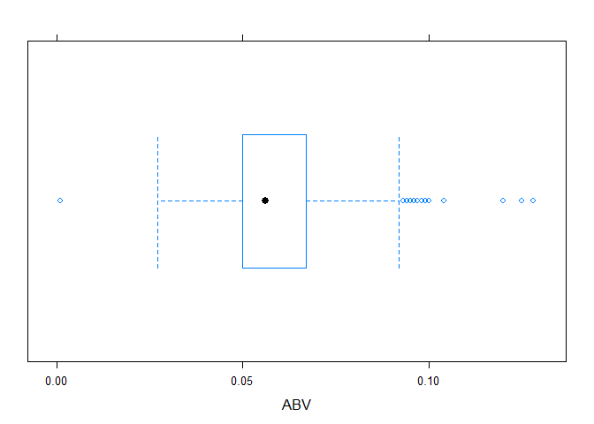

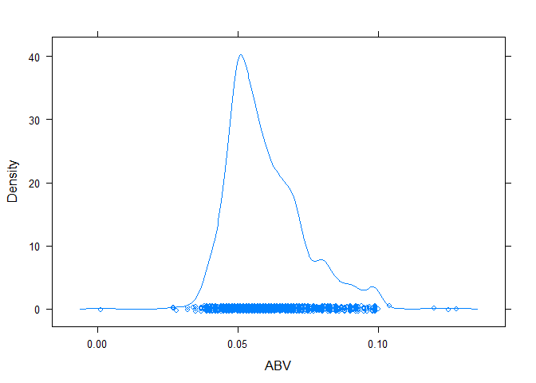

ABV Statistics

| min | Q1 | median | Q3 | max | mean | sd | n | missing |
| --- | --- | --- | --- | --- | --- | --- | --- | --- |
| 0.001 | 0.05 | 0.056 | 0.067 | 0.128 | 0.0597734 | 0.0135417 | 2348 | 62 |

#### Summary IBU variable

The IBU profile of the beers in the study was broader with a greater variance, and a decidedly right skewed curve.

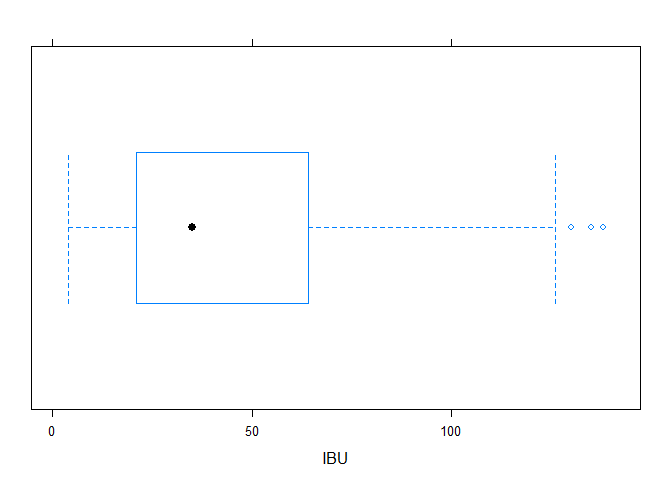

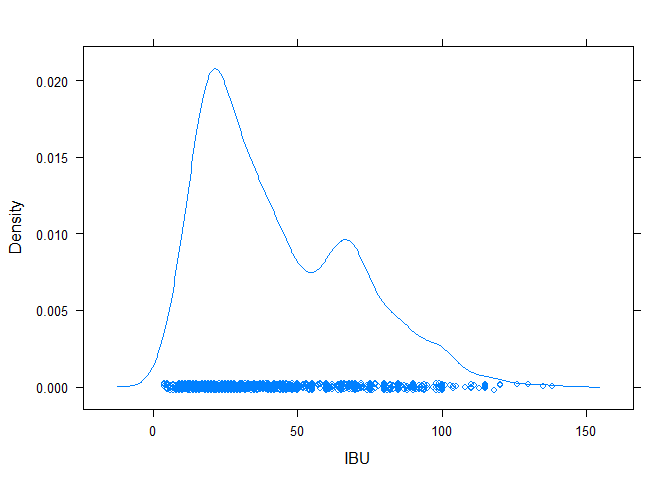

IBU Statistics

| min | Q1 | median | Q3 | max | mean | sd | n | missing |
| --- | --- | --- | --- | --- | --- | --- | --- | --- |
| 4 | 21 | 35 | 64 | 138 | 42.71317 | 25.95407 | 1405 | 1005 |

### Analysis by State

We joined the two datasets on the brewery id, and analysed the beer by state.

Merged Data Summary

| Brewery | City | State | Beer | ABV | IBU | Style | Ounces |
| --- | --- | --- | --- | --- | --- | --- | --- |
| **Top Six Observations** |  |  |  |  |  |  |  |
| NorthGate Brewing | Minneapolis | MN | Pumpion | 0.060 | 38 | Pumpkin Ale | 16 |
| NorthGate Brewing | Minneapolis | MN | Stronghold | 0.060 | 25 | American Porter | 16 |
| NorthGate Brewing | Minneapolis | MN | Parapet ESB | 0.056 | 47 | Extra Special / Strong Bitter (ESB) | 16 |
| NorthGate Brewing | Minneapolis | MN | Get Together | 0.045 | 50 | American IPA | 16 |
| NorthGate Brewing | Minneapolis | MN | Maggie’s Leap | 0.049 | 26 | Milk / Sweet Stout | 16 |
| NorthGate Brewing | Minneapolis | MN | Wall’s End | 0.048 | 19 | English Brown Ale | 16 |
| **Bottom Six Observations** |  |  |  |  |  |  |  |
| Tröegs Brewing Company | Hershey | PA | Perpetual IPA | 0.075 | 85 | American IPA | 12 |
| Tröegs Brewing Company | Hershey | PA | Troegenator Doublebock | 0.082 | 25 | Doppelbock | 16 |
| Mission Brewery | San Diego | CA | Cortez Gold | 0.050 | NA | Belgian Pale Ale | 32 |
| Mission Brewery | San Diego | CA | Mission IPA | 0.068 | 66 | American IPA | 32 |
| Mission Brewery | San Diego | CA | El Conquistador Extra Pale Ale | 0.048 | 44 | American Pale Ale (APA) | 32 |
| Mission Brewery | San Diego | CA | Shipwrecked Double IPA | 0.092 | 75 | American Double / Imperial IPA | 32 |

From the data available it was difficult to determine the density of breweries except for broadly by state. As depicted in the following graphics, states with larger populations, California, Texas, Florida tended toward having more breweries. However, Colorado, strangely enough topped the list with 47 breweries with a population of only 5.6 million compared with [California’s population of 40 Million](https://www.census.gov/programs-surveys/popest.html). We reccommend further investigation of the relationship between breweries and location, possibly supplemented with geo-coordinates of breweries to assess concentrations and regional pallate preferences.

##### Brewery Density by State

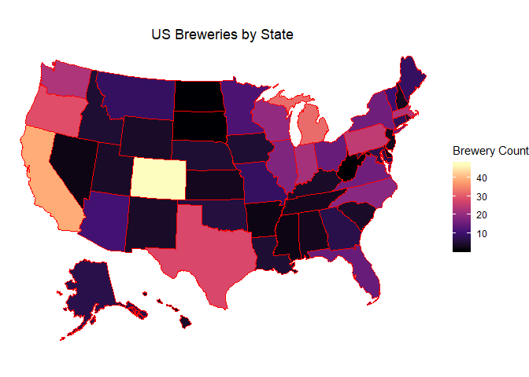

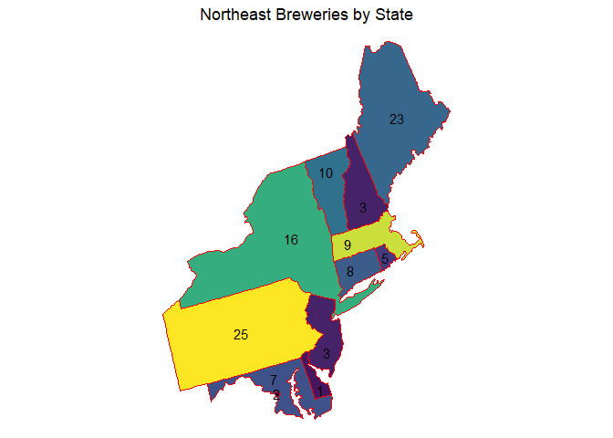

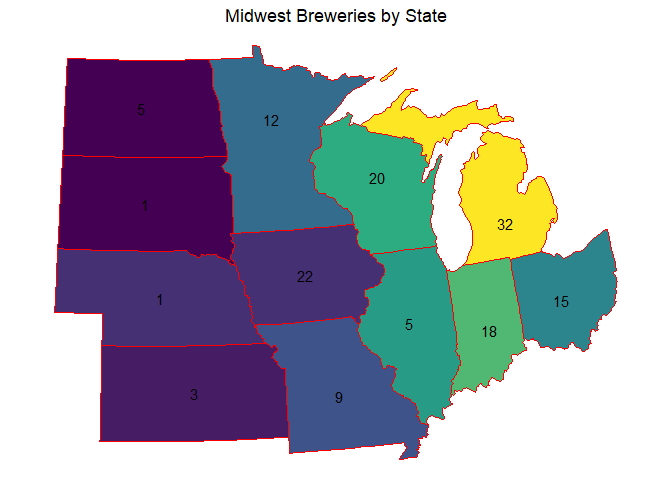

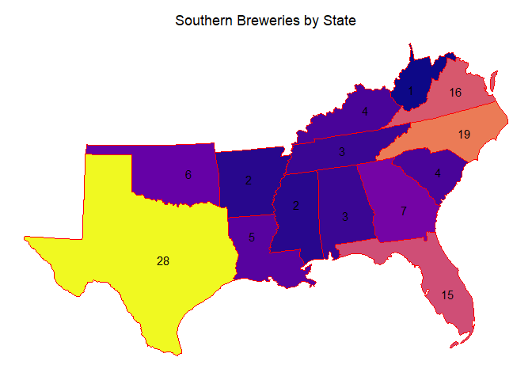

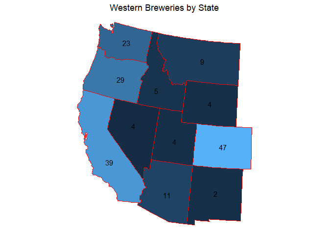

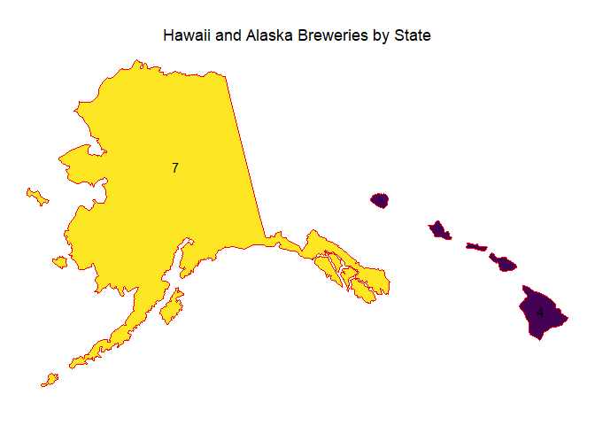

Top 10 Median ABV by State

[output not shown]

Top 10 Median ABV by State

[output not shown]

##### Analysis of Beer Variables by State

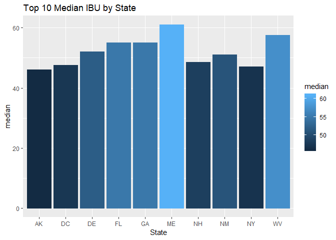

Top 10 Median IBU by State

| State | min | Q1 | median | Q3 | max | mean | sd | n | missing |
| --- | --- | --- | --- | --- | --- | --- | --- | --- | --- |
| ME | 28 | 38.50 | 61.0 | 67.00 | 70 | 52.85714 | 17.43013 | 7 | 20 |
| WV | 44 | 50.75 | 57.5 | 64.25 | 71 | 57.50000 | 19.09188 | 2 | 0 |
| FL | 10 | 25.00 | 55.0 | 65.00 | 82 | 46.75676 | 22.47394 | 37 | 21 |
| GA | 17 | 38.50 | 55.0 | 55.00 | 65 | 46.28571 | 16.23488 | 7 | 9 |
| DE | 52 | 52.00 | 52.0 | 52.00 | 52 | 52.00000 | NA | 1 | 1 |
| NM | 15 | 30.00 | 51.0 | 89.25 | 100 | 57.00000 | 36.71512 | 6 | 8 |
| NH | 15 | 31.75 | 48.5 | 65.25 | 82 | 48.50000 | 47.37615 | 2 | 6 |
| DC | 11 | 14.00 | 47.5 | 88.75 | 115 | 55.25000 | 50.86174 | 4 | 4 |
| NY | 7 | 28.00 | 47.0 | 61.50 | 111 | 46.00000 | 23.41035 | 46 | 28 |
| AK | 10 | 17.00 | 46.0 | 61.00 | 71 | 40.88235 | 23.32617 | 17 | 8 |

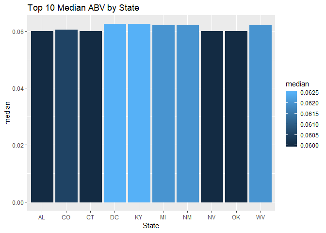

Top 10 Median ABV by State

| State | min | Q1 | median | Q3 | max | mean | sd | n | missing |
| --- | --- | --- | --- | --- | --- | --- | --- | --- | --- |
| DC | 0.050 | 0.0545 | 0.0625 | 0.07250 | 0.092 | 0.0656250 | 0.0144908 | 8 | 0 |
| KY | 0.040 | 0.0500 | 0.0625 | 0.07625 | 0.125 | 0.0646000 | 0.0202105 | 20 | 1 |
| MI | 0.038 | 0.0530 | 0.0620 | 0.06900 | 0.099 | 0.0633775 | 0.0138428 | 151 | 11 |
| NM | 0.045 | 0.0550 | 0.0620 | 0.06600 | 0.080 | 0.0610769 | 0.0099955 | 13 | 1 |
| WV | 0.057 | 0.0595 | 0.0620 | 0.06450 | 0.067 | 0.0620000 | 0.0070711 | 2 | 0 |
| CO | 0.041 | 0.0520 | 0.0605 | 0.07075 | 0.128 | 0.0633720 | 0.0145611 | 250 | 15 |
| AL | 0.050 | 0.0565 | 0.0600 | 0.06000 | 0.093 | 0.0620000 | 0.0124454 | 10 | 0 |
| CT | 0.034 | 0.0500 | 0.0600 | 0.07000 | 0.090 | 0.0610741 | 0.0160526 | 27 | 0 |
| NV | 0.050 | 0.0520 | 0.0600 | 0.07825 | 0.099 | 0.0669000 | 0.0183754 | 10 | 1 |
| OK | 0.040 | 0.0525 | 0.0600 | 0.06800 | 0.085 | 0.0594737 | 0.0131037 | 19 | 0 |

##### State Maximums

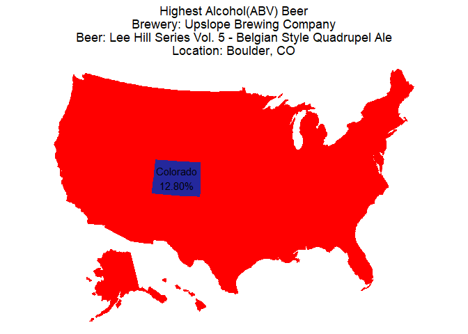

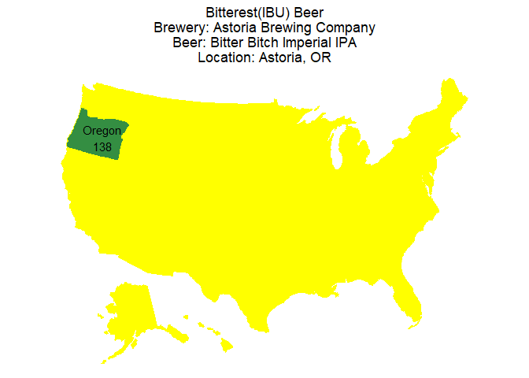

### Relationship between IBU and ABV

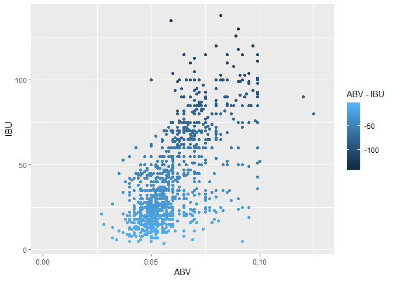

The alcohol content of the beers in the study ranged from ~.001% to 12% with the median and mean landing around 6%. However, the majority of the outliers as evidenced by the ABV boxplot shows a tendency towards the higher and of the range from 10-12%. This hints at a potential trend towards higher alcohol content preferences. Further, investigation along this line would be to determine whether or not there is a regional preference for beers with higher alcohol content.

Alcohol Content and Bitterness showed a correlation, but the strength of that correlation was not examined in this analysis.

Further investigation is recommended for determining geographic significance or breweries and testing for regional palates.